# Les échecs comme problème de recherche

Un complément à la présentation 16 sur la recherche en largeur

Auteur·rice

Marcel Turcotte

## Objectifs d’apprentissage

Ce complément d’autoapprentissage applique la terminologie de la recherche et la recherche en largeur (*breadth-first search*, BFS) de la présentation 16 à un puzzle soumis à une contrainte. Il utilise les règles de déplacement des pièces d’échecs sans simuler une partie complète. BFS fournit un point de comparaison pour étudier des méthodes de recherche plus avancées dans les présentations suivantes.

À la fin de cet exemple, nous serons capables de :

- formuler un puzzle en termes d’états, d’actions, de transitions, d’une contrainte, d’un test d’objectif et d’un coût de chemin ;
- expliquer comment la contrainte de sécurité détermine les actions disponibles ;
- expliquer l’importance de la détection des états répétés ;
- utiliser BFS pour trouver une solution comportant le moins de coups possible et décrire ce que la recherche a exploré.

## Le puzzle

Ce problème est inspiré d’un exercice de [Lichess Learn](https://lichess.org/learn#/9/5).

Les Blancs jouent successivement ; les Noirs ne jouent jamais. Les Blancs doivent capturer toutes les pièces noires en aussi peu de coups que possible. Après chaque coup des Blancs, toute pièce blanche attaquée par une pièce noire doit être défendue par une autre pièce blanche.

La position initiale peut enfreindre cette règle de sécurité. Elle est même délibérément non sûre : le premier coup des Blancs doit corriger le problème.

### Formulation du problème de recherche

| Composante | Définition dans ce puzzle |
| --- | --- |
| **État** | La position et le type de toutes les pièces |
| **État initial** | La position encodée ci-dessous en notation FEN |
| **Actions** | Les coups pseudo-légaux des Blancs dont les états résultants respectent la contrainte de sécurité |
| **Modèle de transition** | Déplacer une pièce blanche ; retirer une pièce noire capturée ; promouvoir un pion qui atteint la dernière rangée |
| **Contrainte de validité** | Toute pièce blanche attaquée est défendue |
| **Test d’objectif** | Il ne reste aucune pièce noire |
| **Coût d’une action** | Une unité par coup des Blancs |

Le **coût du chemin** est le nombre de coups des Blancs. Toutes les actions ont le même coût ; BFS trouve donc une solution comportant le moins de coups possible. L’implémentation énumère d’abord les *actions candidates* selon les règles de déplacement des pièces, puis conserve uniquement celles dont les états résultants respectent la contrainte de sécurité.

## Configuration et position initiale

Pour utiliser votre propre environnement de carnets Python, installez les dépendances une seule fois, puis sélectionnez le noyau de cet environnement :

```bash
python -m pip install chess resvg-py ipykernel
```

```python
from collections import deque
from dataclasses import dataclass
from typing import Optional

import chess
import chess.svg
import resvg_py
from IPython.display import Image, Markdown, display
```

**Fonction d’affichage de l’échiquier**

```python
def board_image(
    position,
    *,
    display_size=420,
    scale=2,
    lastmove=None,
    fill=None,
):
    """Retourne un échiquier PNG à haute résolution pour le carnet."""
    svg_options = {
        "board": position,
        "size": display_size * scale,
    }

    if lastmove is not None:
        svg_options["lastmove"] = lastmove
    if fill is not None:
        svg_options["fill"] = fill

    svg = chess.svg.board(**svg_options)
    png = resvg_py.svg_to_bytes(svg_string=svg)

    return Image(data=png, width=display_size)
```

La notation FEN décrit l’échiquier rangée par rangée, de la rangée 8 à la rangée 1. Les lettres majuscules représentent les pièces blanches ; les minuscules, les pièces noires. Le `w` indique que les Blancs jouent ensuite.

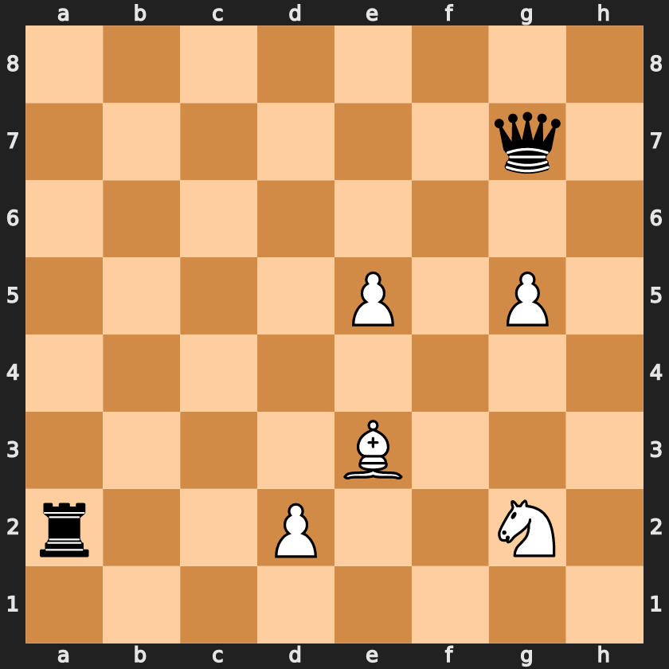

```python
START_FEN = "8/6q1/8/4P1P1/8/4B3/r2P2N1/8 w - - 0 1"

board = chess.Board(START_FEN)
display(board_image(board))
```

La position contient une tour noire en a2 et une dame noire en g7. Les Blancs ont des pions en d2, e5 et g5, un fou en e3 et un cavalier en g2. Les rois sont inutiles dans ce puzzle ; nous utilisons donc des déplacements *pseudo-légaux* plutôt que les règles de mise en échec. La promotion habituelle des pions est autorisée ; le roque et la prise en passant sont absents.

## Test d’objectif

Un état objectif ne contient aucune pièce noire. Exprimer l’objectif sous forme d’un petit prédicat indépendant facilite sa vérification et sa réutilisation.

```python
def is_goal(position):
    """Retourne True exactement lorsqu'il ne reste aucune pièce noire."""
    return not any(
        piece.color == chess.BLACK
        for piece in position.piece_map().values()
    )


assert not is_goal(board)
```

## La contrainte de sécurité

Soit $T(p,s)$ le fait qu’une pièce noire attaque la pièce blanche $p$ dans l’état $s$, et $D(p,s)$ le fait qu’une autre pièce blanche la défend. Un état valide après un coup satisfait

$$\forall p \in W(s), \qquad T(p,s) \Rightarrow D(p,s).$$

Une pièce blanche qui n’est pas attaquée n’a pas besoin d’être défendue. La sécurité est une propriété de la *position résultante entière*, et pas seulement de la pièce qui vient de bouger.

```python
def threatened_white_squares(position):
    """Retourne les cases des pièces blanches attaquées par les Noirs."""
    return {
        square
        for square, piece in position.piece_map().items()
        if piece.color == chess.WHITE
        and position.attackers(chess.BLACK, square)
    }


def undefended_white_squares(position):
    """Retourne les cases des pièces blanches attaquées et non défendues."""
    return {
        square
        for square in threatened_white_squares(position)
        if not position.attackers(chess.WHITE, square)
    }


def is_safe(position):
    """
    Détermine si une position respecte la règle de sécurité du puzzle.

    Une position est sûre si chaque pièce blanche attaquée par au moins une
    pièce noire est défendue par au moins une autre pièce blanche. Les pièces
    blanches qui ne sont pas attaquées n'ont pas besoin d'être défendues.
    """
    return not undefended_white_squares(position)


initial_problems = sorted(
    chess.square_name(square) for square in undefended_white_squares(board)
)
print("Pièces blanches non sûres dans l'état initial :", initial_problems)
assert not is_safe(board)
assert initial_problems == ["e5"]
```

```
Pièces blanches non sûres dans l'état initial : ['e5']
```

La sortie confirme l’interprétation voulue du puzzle : le pion en e5 est attaqué par la dame et n’a aucun défenseur.

## Vérifications : coups autorisés et interdits

Avant de lancer la recherche, nous devons vérifier la règle de transition à l’aide d’exemples dont nous connaissons déjà les réponses. La fonction ci-dessous applique un coup des Blancs et leur redonne le trait, puisque les Noirs ne jouent jamais dans ce puzzle.

Les coups utilisent la **notation UCI** : `e5e6` déplace une pièce de e5 à e6. Une lettre finale indique une promotion : `e7e8q` déplace un pion en e8 et le promeut en dame.

```python
def after(position, uci):
    """Retourne l'état après un coup pseudo-légal des Blancs en notation UCI."""
    parent = position.copy(stack=False)
    parent.turn = chess.WHITE
    move = chess.Move.from_uci(uci)

    if move not in parent.pseudo_legal_moves:
        raise ValueError(f"{uci} n'est pas un coup pseudo-légal des Blancs")

    parent.push(move)
    parent.turn = chess.WHITE
    return parent


expected = {
    "e3f4": True,   # Le fou défend maintenant e5.
    "e5e6": True,   # Le pion se soustrait à l'attaque de la dame.
    "g2h4": False,  # Le problème initial en e5 persiste.
    "d2d3": False,  # La tour attaque maintenant le cavalier non défendu en g2.
}

for uci, should_be_safe in expected.items():
    child = after(board, uci)
    problems = sorted(
        chess.square_name(square)
        for square in undefended_white_squares(child)
    )
    result = is_safe(child)
    print(
        f"{uci}: {'autorisé' if result else 'interdit':9s} "
        f"(non défendues : {problems or 'aucune'})"
    )
    assert result == should_be_safe
```

```
e3f4: autorisé  (non défendues : aucune)
e5e6: autorisé  (non défendues : aucune)
g2h4: interdit  (non défendues : ['e5'])
d2d3: interdit  (non défendues : ['e5', 'g2'])
```

Ces exemples montrent pourquoi la validité doit être vérifiée *après* l’application d’une action. Par exemple, `g2h4` est un déplacement normal du cavalier, mais il est interdit parce que l’état résultant laisse encore e5 attaqué et non défendu.

## Génération des successeurs valides

La génération des successeurs comporte trois étapes conceptuelles :

$$\begin{aligned}
\text{action candidate}
&\longrightarrow \text{appliquer la transition} \\
&\longrightarrow
\text{conserver l'état seulement s'il est sûr}.
\end{aligned}$$

```python
def expand(position):
    """Produit `(move, child)` pour chaque état sûr à un coup des Blancs."""
    parent = position.copy(stack=False)
    parent.turn = chess.WHITE

    for move in parent.pseudo_legal_moves:
        child = parent.copy(stack=False)
        child.push(move)
        child.turn = chess.WHITE

        if is_safe(child):
            yield move, child


first_moves = [move.uci() for move, _ in expand(board)]
print(f"L'état initial possède {len(first_moves)} successeurs valides :")
print(first_moves)

assert "e3f4" in first_moves
assert "e5e6" in first_moves
assert "g2h4" not in first_moves
assert "d2d3" not in first_moves
```

```
L'état initial possède 2 successeurs valides :
['e3f4', 'e5e6']
```

## États répétés et clé d’état

Plusieurs chemins peuvent mener au même arrangement. Les pièces peuvent aussi se déplacer puis revenir à leur position précédente, créant des cycles. Sans détection des états répétés, BFS perdrait du temps à redécouvrir ces positions.

Seule la disposition des pièces affecte les décisions futures dans ce puzzle : les Blancs jouent toujours, il n’y a ni roque ni prise en passant, et les compteurs de coups n’ont aucune importance. `board_fen()` fournit donc une clé d’état appropriée sans conserver les données administratives inutiles de la notation FEN complète.

```python
def state_key(position):
    """Retourne la partie de l'état qui importe pour les décisions futures."""
    return position.board_fen()


assert state_key(board) == START_FEN.split()[0]
```

Il s’agit d’une leçon générale de modélisation : un état de recherche doit conserver tout ce qui peut affecter l’avenir, mais pas nécessairement tout ce qu’une bibliothèque enregistre.

## Recherche en largeur

La frontière conserve les nœuds de recherche sous forme de paires `(state, path)`. Ici, `path` est une séquence d’**actions** (coups d’échecs) ; l’implémentation de la présentation 16 enregistre plutôt la séquence des **états** le long d’un chemin. Les deux décrivent comment atteindre l’état du nœud depuis l’état initial.

L’ensemble `reached` contient les états de la frontière et les états déjà développés. Il évite de répéter le travail. Les compteurs révèlent l’effort de recherche qui serait autrement caché derrière la réponse finale.

```python
@dataclass(frozen=True)
class SearchStats:
    solution_depth: Optional[int]
    states_expanded: int
    states_generated: int
    duplicate_states: int
    max_frontier_size: int
    reached_states: int


def bfs(start):
    """Trouve une solution avec le moins de coups par BFS sur graphe."""
    root = start.copy(stack=False)
    root.turn = chess.WHITE

    frontier = deque([(root, [])])
    reached = {state_key(root)}

    expanded = 0
    generated = 0
    duplicates = 0
    max_frontier = len(frontier)

    while frontier:
        position, path = frontier.popleft()

        # BFS teste les états par longueur de chemin non décroissante.
        if is_goal(position):
            stats = SearchStats(
                solution_depth=len(path),
                states_expanded=expanded,
                states_generated=generated,
                duplicate_states=duplicates,
                max_frontier_size=max_frontier,
                reached_states=len(reached),
            )
            return path, stats

        expanded += 1

        for move, child in expand(position):
            generated += 1
            key = state_key(child)

            if key in reached:
                duplicates += 1
                continue

            reached.add(key)
            frontier.append((child, path + [move]))
            max_frontier = max(max_frontier, len(frontier))

    stats = SearchStats(
        solution_depth=None,
        states_expanded=expanded,
        states_generated=generated,
        duplicate_states=duplicates,
        max_frontier_size=max_frontier,
        reached_states=len(reached),
    )
    return None, stats
```

Le code effectue une **recherche sur graphe** (*graph search*) : `reached` garantit que chaque disposition distincte des pièces entre dans la frontière au plus une fois. Ici, « générés » compte les successeurs valides avant le retrait des doublons, tandis que « développés » compte les états non objectifs retirés de la frontière et examinés.

## Exécuter et examiner la recherche

```python
solution, stats = bfs(board)

if solution is None:
    print("Aucune solution trouvée.")
else:
    print(f"Longueur minimale de la solution : {len(solution)} coups")
    print("Coups :", " ".join(move.uci() for move in solution))

print()
print(f"États développés :              {stats.states_expanded:,}")
print(f"États générés :                 {stats.states_generated:,}")
print(f"États répétés :                 {stats.duplicate_states:,}")
print(f"Taille maximale de la frontière : {stats.max_frontier_size:,}")
print(f"États distincts atteints :      {stats.reached_states:,}")

assert solution is not None
assert len(solution) == stats.solution_depth
```

```
Longueur minimale de la solution : 8 coups
Coups : e5e6 g2h4 h4f5 f5g7 e6e7 e7e8q e8g8 g8a2

États développés :              4,101
États générés :                 50,202
États répétés :                 34,959
Taille maximale de la frontière : 11,143
États distincts atteints :      15,244
```

La solution est la plus courte parce que chaque arête coûte un coup et que BFS examine les états moins profonds avant les états plus profonds. Les statistiques montrent aussi que la file n’est qu’une partie de l’algorithme : la représentation des états, le filtrage selon la contrainte et la détection des doublons influencent tous la recherche de façon importante.

## Visualiser la solution

L’affichage ci-dessous commence par l’état initial, puis montre chaque coup de la solution minimale. Le dernier coup est mis en évidence par `lastmove`. Les cases dorées indiquent les pièces blanches actuellement attaquées par les Noirs ; puisque tous les états après un coup sont valides, chacune de ces pièces a aussi un défenseur blanc.

**Fonction d’affichage et relecture de la solution**

```python
THREATENED_COLOR = "#f2c14e99"


def display_solution(start, moves, size=380):
    """Affiche l'état initial et chaque position annotée d'un chemin."""
    current = start.copy(stack=False)
    current.turn = chess.WHITE

    display(Markdown("### Position initiale"))
    display(board_image(current, display_size=size))

    for number, move in enumerate(moves, start=1):
        assert move in current.pseudo_legal_moves
        current.push(move)
        current.turn = chess.WHITE

        threatened = threatened_white_squares(current)
        names = sorted(chess.square_name(square) for square in threatened)
        annotation = ", ".join(names) if names else "aucune"
        fill = {square: THREATENED_COLOR for square in threatened}

        display(
            Markdown(
                f"\n### Coup {number} : `{move.uci()}`\n\n"
                f"Pièces blanches attaquées et défendues : {annotation}.\n"
            )
        )
        display(
            board_image(
                current,
                display_size=size,
                lastmove=move,
                fill=fill,
            )
        )

        # Chaque état affiché après un coup doit respecter la contrainte.
        assert is_safe(current)

    assert is_goal(current)


display_solution(board, solution)
```

### Position initiale

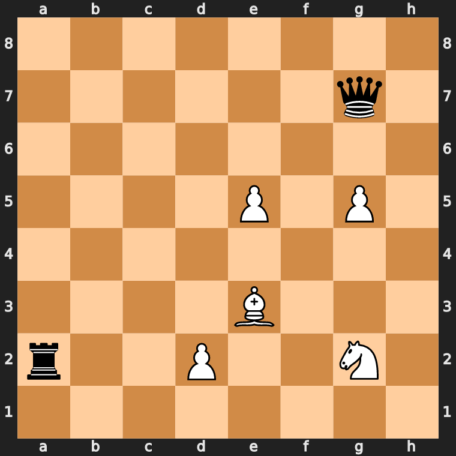

### Coup 1 : `e5e6`

Pièces blanches attaquées et défendues : d2, g5.

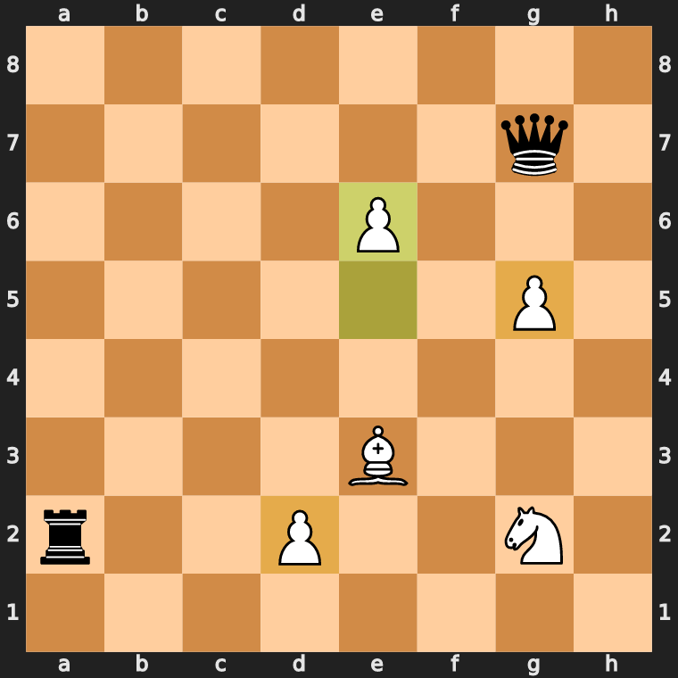

### Coup 2 : `g2h4`

Pièces blanches attaquées et défendues : d2, g5.

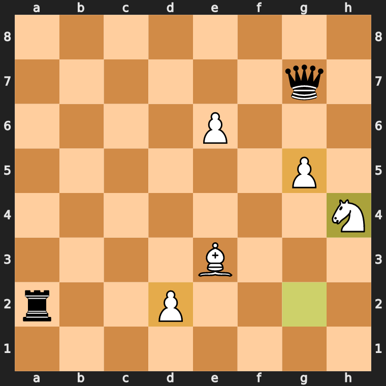

### Coup 3 : `h4f5`

Pièces blanches attaquées et défendues : d2, g5.

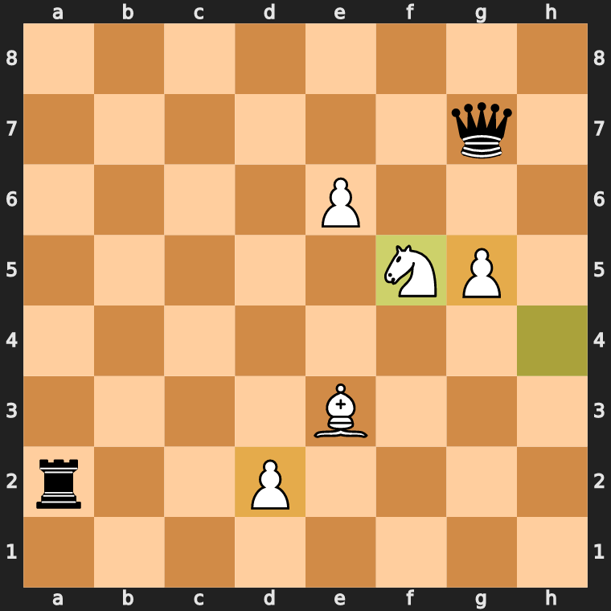

### Coup 4 : `f5g7`

Pièces blanches attaquées et défendues : d2.

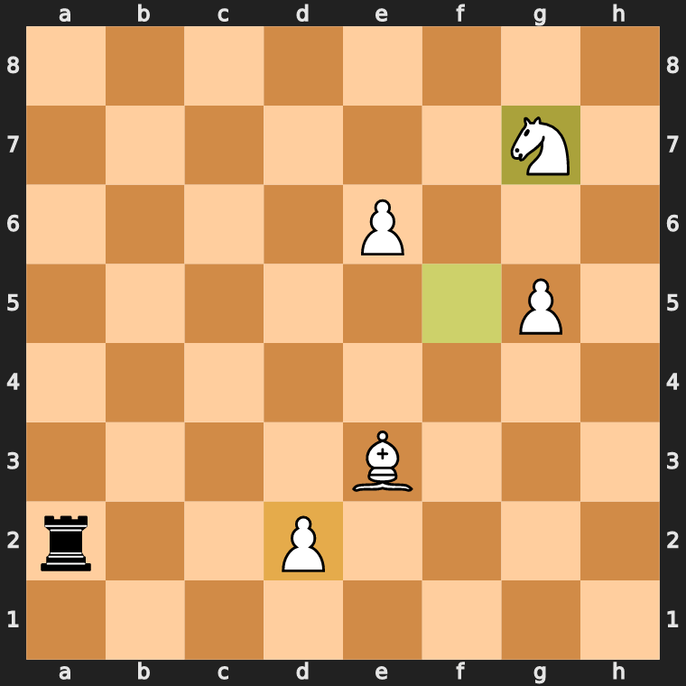

### Coup 5 : `e6e7`

Pièces blanches attaquées et défendues : d2.

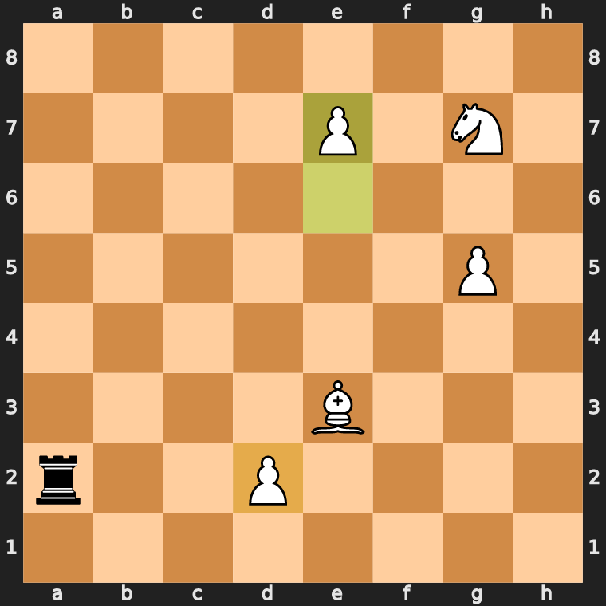

### Coup 6 : `e7e8q`

Pièces blanches attaquées et défendues : d2.

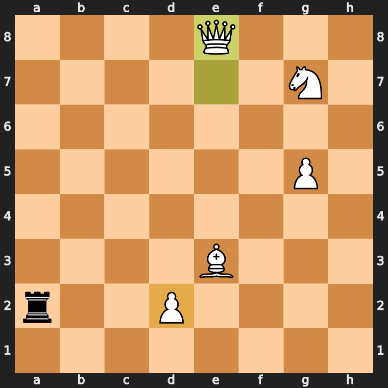

### Coup 7 : `e8g8`

Pièces blanches attaquées et défendues : d2.

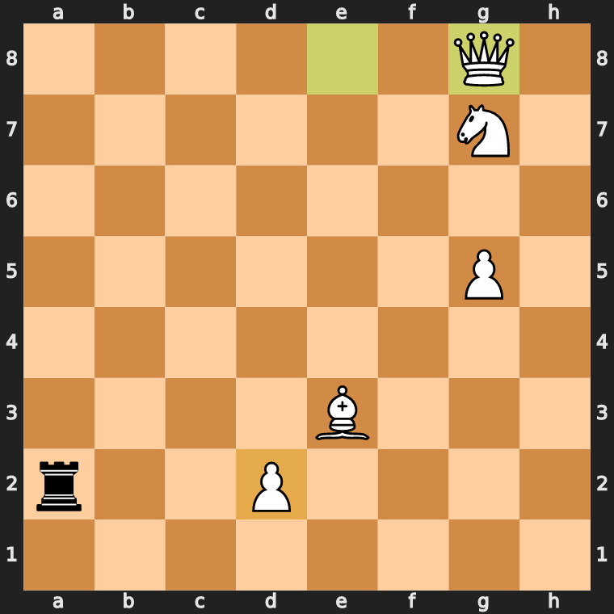

### Coup 8 : `g8a2`

Pièces blanches attaquées et défendues : aucune.

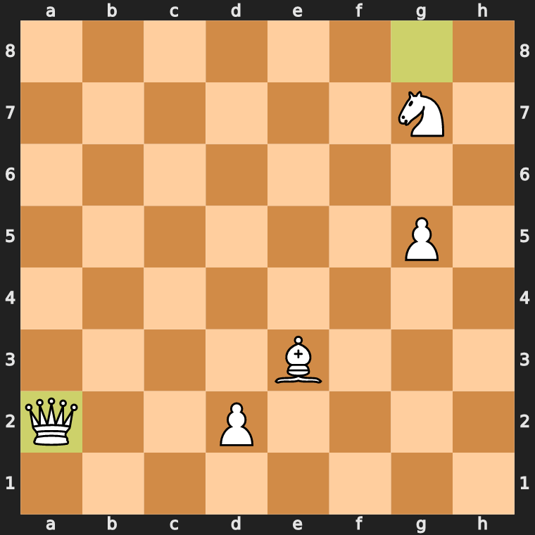

## Questions de réflexion

1. Que se passerait-il sans `reached` si un cavalier passait d’une case à une autre, puis revenait à sa case initiale ?
2. Pourquoi BFS minimise-t-il le nombre de coups dans ce puzzle ?

### Prolongements pour les présentations suivantes

- **Présentation 17 — Recherche informée :** Comment l’algorithme changerait-il si les coups avaient des coûts différents ? Quelles informations sur l’échiquier pourraient fournir une heuristique utile pour la recherche gloutonne (*greedy best-first search*) ou A* ?
- **Présentation 21 — Recherche adversariale :** Comment le problème changerait-il si les Noirs pouvaient choisir une réponse ?

La dernière question fait le lien entre la recherche à un seul agent et la recherche adversariale : dès que les Noirs choisissent aussi leurs coups, les modèles suivants sont naturellement minimax et l’élagage alpha-bêta plutôt que BFS dans un environnement passif.